# Trend Analysis

Nik Bear Brown

In this lesson we’ll learn the how to implement Trend Analysis in R.

# Additional packages needed

To run the code you may need additional packages.

- If necessary install the followings packages.

`install.packages("tseries");`

```r
library(tseries)
```

# Data

We will be generating simulated data for this lesson.

# Trend Analysis

Trend Analysis is the practice of collecting information and attempting to spot a pattern, or trend, in the information. Typically this involves analyzing the variance for a change over time. The null hypothesis: $H_0$ is that there is no trend. Many techniques can be used to identify trends, we’ll use an ARMA model again.

# Dickey-Fuller Test

The Dickey-Fuller Test is a test for the stationarity of a time series.

The [Dickey-Fuller test](https://en.wikipedia.org/wiki/Dickey%E2%80%93Fuller_test) tests whether a unit root is present in an autoregressive model. simple AR(1) model is
$$y_{t}=\rho y_{t-1}+u_{t}\,$$

where $y_{t}$ is the variable of interest, $t$ is the time index, $\rho$ is a coefficient, and $u_{t}$ is the error term. A unit root is present if $\rho = 1$. The model would be non-stationary in this case.

The regression model can be written as
$$\nabla y_{t}=(\rho-1)y_{t-1}+u_{t}=\delta y_{t-1}+ u_{t}\,$$
where $\nabla$ is the first difference operator.

The Dickey-Fuller Test uses a specific distribution simply known as the Dickey-Fuller table to assess whether $\nabla y_{t}$ is signficant.

# Trend Analysis in R

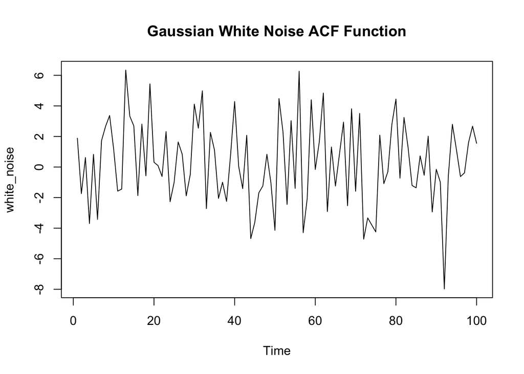

```r
#-----------  White noise  --------
set.seed(3333)
white_noise <- rnorm(100, mean = 0, sd = 3.0)
plot(white_noise,type='l',xlab='Time',main='Gaussian White Noise ACF Function')
```

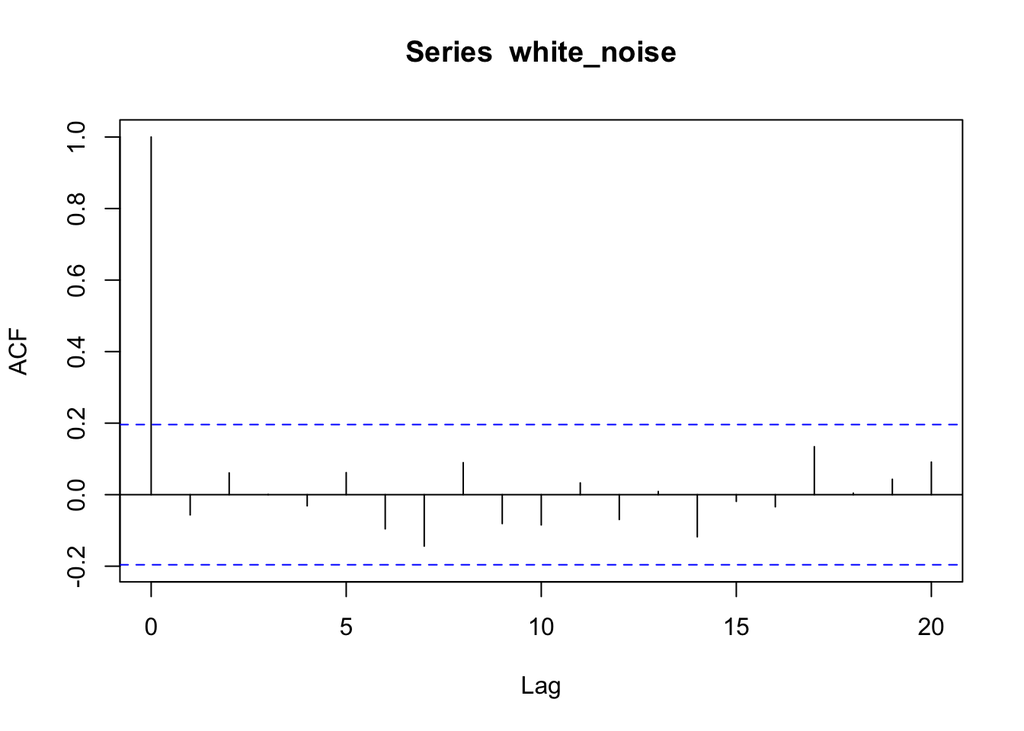

```r
## Fitting White noise Time series
# plot a correlogram
acf(white_noise)
```

```r
var(white_noise)
```

```
## [1] 7.576885
```

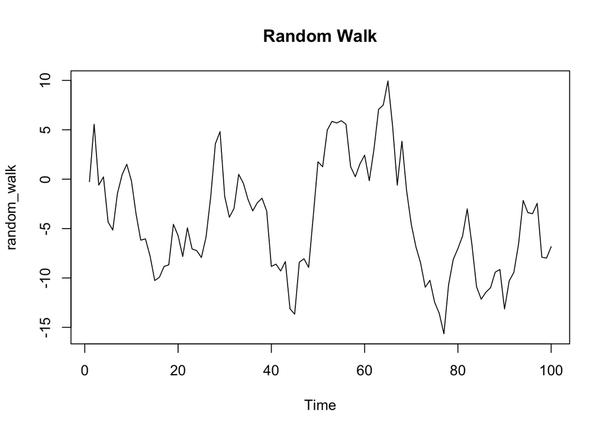

```r
#------------- Random Walk -------------
#To simulate a random walk in R, we essentially need a cumulative sum of a white noise random series.
set.seed(333)
random_walk <- cumsum(rnorm(100, mean = 0, sd = 3.0))
plot(random_walk,type='l',xlab='Time',main='Random Walk')
```

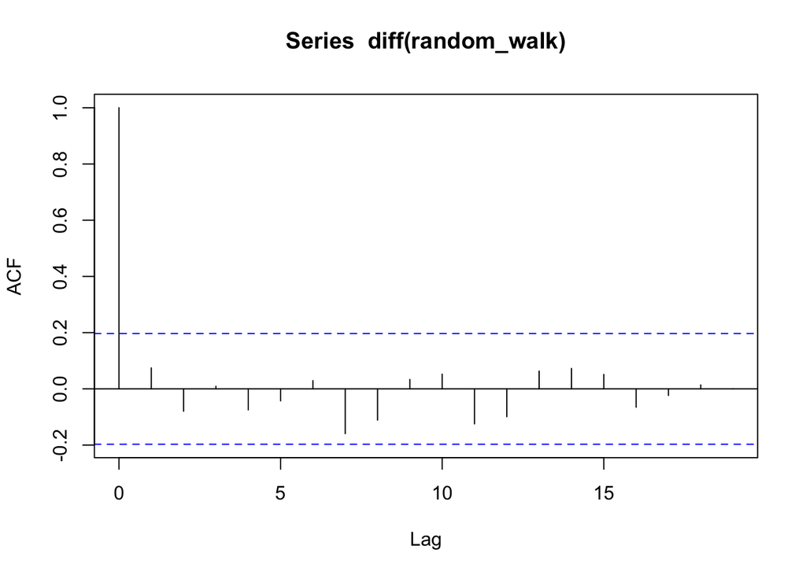

```r
# Fitting a Random Walk
#A good way to see if a time series follows a random walk is to compute the successive differences between terms.
acf(diff(random_walk))
```

```r
#----------------------------- ARMA model  ----------------------

                               # Moving Average Model

set.seed(555)
#ACF function with coefficients 0.84 and 0.62
ma_ts1 <- arima.sim(model = list(ma = c(0.84, 0.62), sd = 1.2), n = 1000)
head(ma_ts1, n = 8)
```

```
## [1]  0.59291917  2.51535102  0.03864703  0.56145710 -0.51638224  1.78195701
## [7]  1.08566382  1.49532881
```

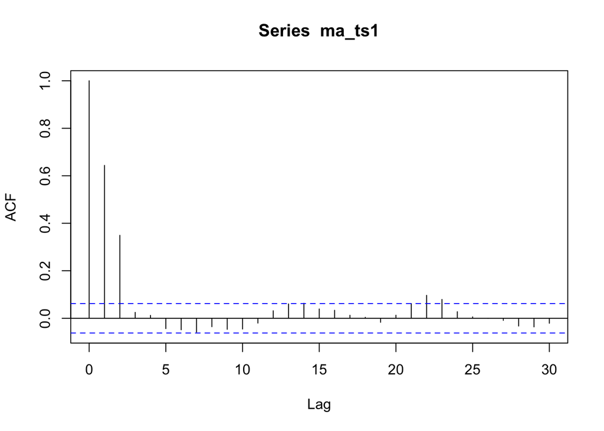

```r
acf(ma_ts1)
```

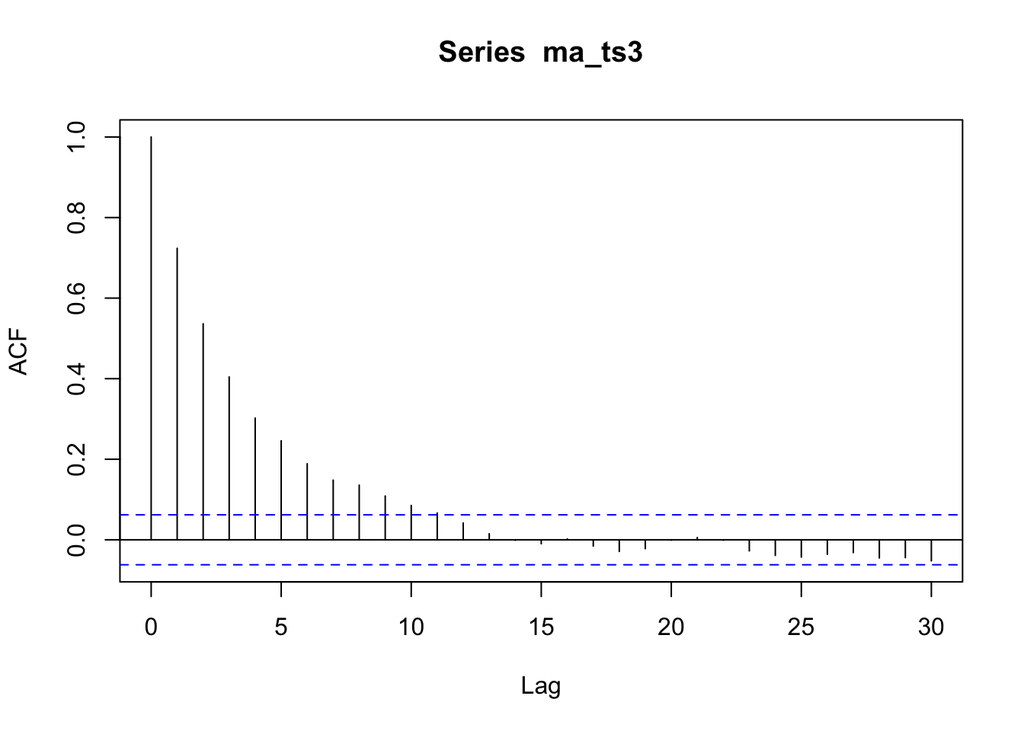

```r
#  Autoregressive model
set.seed(5555)
ma_ts3 <- arima.sim(model = list(ar = c(0.74), sd = 1.2), n = 1000)
acf(ma_ts3)
```

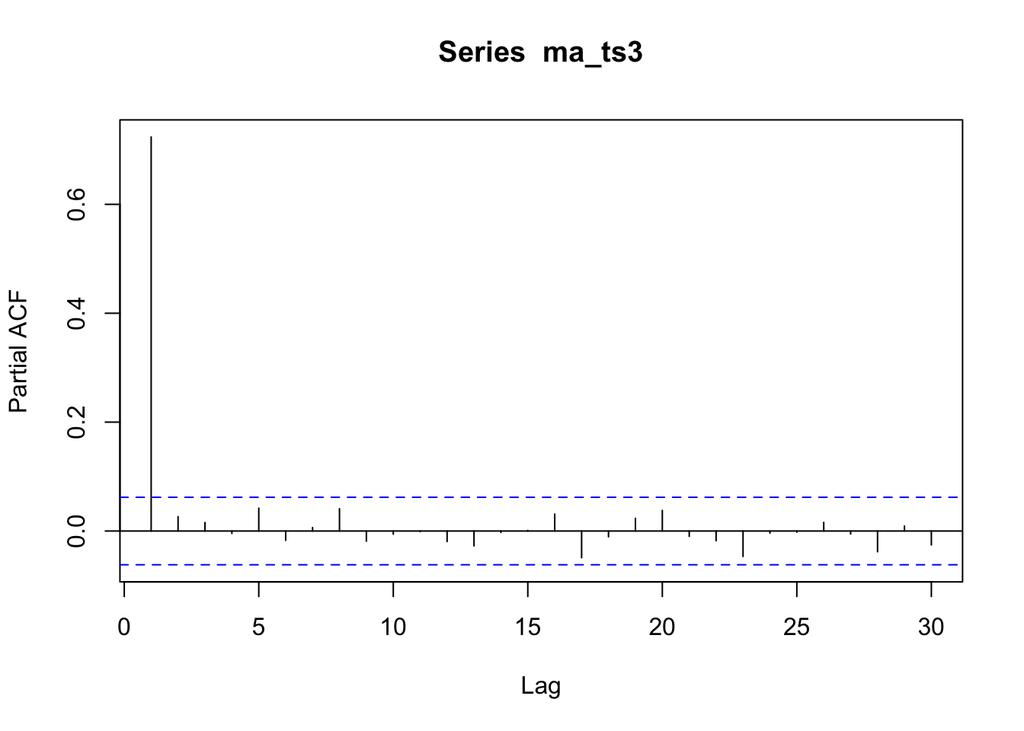

```r
pacf(ma_ts3)
```

```r
#--------------Dickey-Fuller for stationarity -----------------------
adf.test(random_walk, alternative = "stationary")
```

```
##
##  Augmented Dickey-Fuller Test
##
## data:  random_walk
## Dickey-Fuller = -2.7267, Lag order = 4, p-value = 0.2756
## alternative hypothesis: stationary
```

```r
#------------ Another unit root test : Philips-Perron test -------
PP.test(random_walk)
```

```
##
##  Phillips-Perron Unit Root Test
##
## data:  random_walk
## Dickey-Fuller = -2.8444, Truncation lag parameter = 3, p-value =
## 0.2268
```

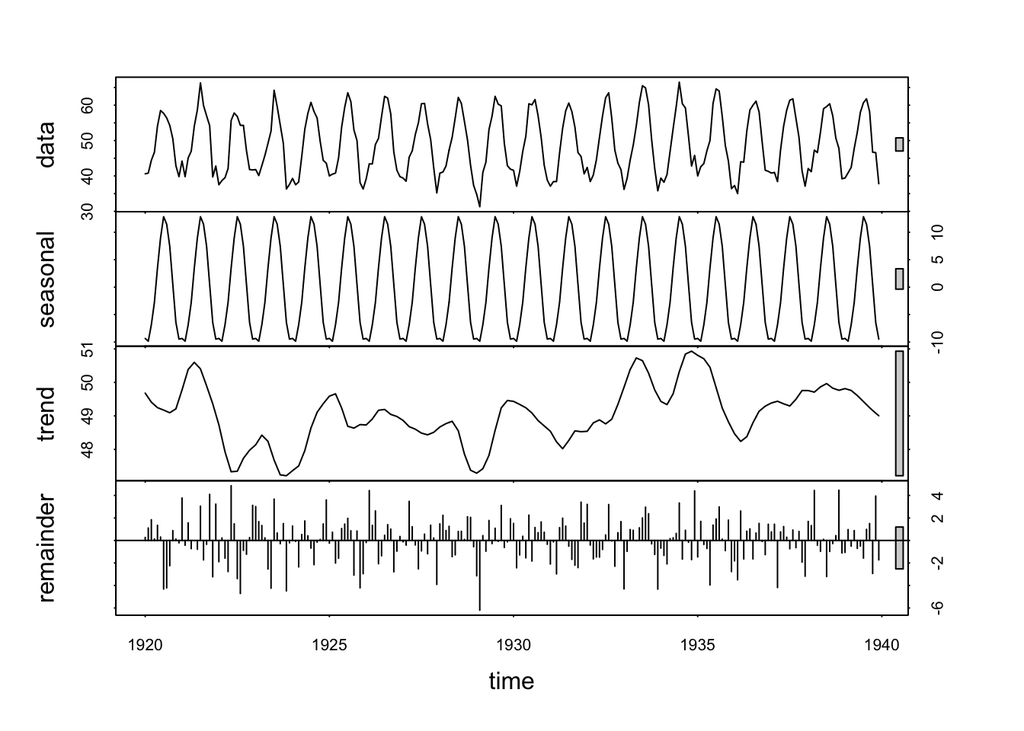

```r
# ------------     Seasonal Trend Decomposition in R  --------

#The Seasonal Trend Decomposition using Loess (STL) is an algorithm that was developed
#to help to divide up a time series into three components namely: the trend, seasonality and remainder.
nottem.stl = stl(nottem, s.window="periodic")
plot(nottem.stl)
```

# Resources

- The heat is on.. or is it? Trend Analysis of Toronto Climate Data via @rbloggers](http://www.r-bloggers.com/the-heat-is-on-or-is-it-trend-analysis-of-toronto-climate-data/)
- [Trend Analysis - ETH](http://www.iac.ethz.ch/edu/courses/master/electives/acwd/Trend.pdf)
- [Trend Analysis Using R - ResearchGate](http://www.researchgate.net/publication/275640899_Trend_Analysis_Using_R)

# References

The data, R code and lessons are based upon:

1. Time Series Analysis :

Data Source: http://www.geophysics.geol.uoa.gr/catalog/catgr_20002008.epi

Code References :

Book : Mastering Predictive Analytic with R  
Author: Rui Miguel Forte  
https://www.safaribooksonline.com/library/view/mastering-predictive-analytics/9781783982806/

Chapter 9: Time series Analysis

http://www.statoek.wiso.uni-goettingen.de/veranstaltungen/zeitreihen/sommer03/ts_r_intro.pdf

http://www.stat.pitt.edu/stoffer/tsa3/R_toot.htm

http://www.statoek.wiso.uni-goettingen.de/veranstaltungen/zeitreihen/sommer03/ts_r_intro.pdf

2. Trend Analysis

Code References :

Book : Mastering Predictive Analytic with R  
Author: Rui Miguel Forte  
https://www.safaribooksonline.com/library/view/mastering-predictive-analytics/9781783982806/

http://www.r-bloggers.com/seasonal-trend-decomposition-in-r/

3. Seasonal Models

Code references :

Book: Time Series Analysis and Its Applications  
Author: Robert H. Shumway . David S. Stoffer  
Link: http://www.springer.com/us/book/9781441978646#otherversion=9781461427599

http://a-little-book-of-r-for-time-series.readthedocs.org/en/latest/src/timeseries.html

https://onlinecourses.science.psu.edu/stat510/?q=node/47

https://rpubs.com/ryankelly/tsa5

https://onlinecourses.science.psu.edu/stat510/node/68

Data Reference : https://github.com/RMDK/TimeSeriesAnalysis/blob/master/colorado_river.csv

4. Spectral Analysis

Code References:  
Book:  
Modern Applied Statistics with S Fourth edition  
Author: W. N. Venables and B. D. Ripley  
Link: Modern Applied Statistics with S Fourth edition

http://www.maths.adelaide.edu.au/patty.solomon/TS2004/tsprac3_2004.pdf